# HW3

Haoran Zhang

2021/11/3

```r
library(httr)
library(rvest)
library(xml2)
library(data.table)
library(stringr)
library(dplyr)
library(ggplot2)
library(tidytext)
library(tidyverse)
```

## APIs

1. Using the NCBI API, look for papers that show up under the term “sars-cov-2 trial vaccine.” Look for the data in the pubmed database, and then retrieve the details of the paper as shown in lab 7. How many papers were you able to find?

```r
# Downloading the website
website <- xml2::read_html("https://pubmed.ncbi.nlm.nih.gov/?term=sars-cov-2+trial+vaccine")
# Finding the counts
counts <- xml2::xml_find_first(website, "/html/body/main/div[9]/div[2]/div[2]/div[1]/div[1]/span")
# Turning it into text
counts <- as.character(counts)
# Extracting the data using regex
stringr::str_extract(counts, "[0-9,]+")
```

```
## [1] "2,335"
```

```r
stringr::str_extract(counts, "[[:digit:],]+")
```

```
## [1] "2,335"
```

```r
stringr::str_replace(counts, "[^[:digit:]]+([[:digit:]]+),([[:digit:]]+)[^[:digit:]]+", "\\1\\2")
```

```
## [1] "2335"
```

2. Using the list of pubmed ids you retrieved, download each papers’ details using the query parameter rettype = abstract. If you get more than 250 ids, just keep the first 250.

```r
query_ids <- GET(
  url   = "https://eutils.ncbi.nlm.nih.gov/entrez/eutils/esearch.fcgi",
  query = list(
    db = "pubmed",
    term = "sars-cov-2 trial vaccine",
    retmax = 250)
)

GET(
  url   = "https://eutils.ncbi.nlm.nih.gov/",
  path  = "entrez/eutils/esearch.fcgi",
  query = list(
    db     = "pubmed",
    term   = "sars-cov-2 trial vaccine",
    retmax = 250
    )
)
```

```
## Response [https://eutils.ncbi.nlm.nih.gov/entrez/eutils/esearch.fcgi?db=pubmed&term=sars-cov-2%20trial%20vaccine&retmax=250]
##   Date: 2021-11-05 01:07
##   Status: 200
##   Content-Type: text/xml; charset=UTF-8
##   Size: 7.76 kB
## <?xml version="1.0" encoding="UTF-8" ?>
## <!DOCTYPE eSearchResult PUBLIC "-//NLM//DTD esearch 20060628//EN" "https://eu...
## <eSearchResult><Count>1044</Count><RetMax>250</RetMax><RetStart>0</RetStart><...
## <Id>34729549</Id>
## <Id>34726743</Id>
## <Id>34715931</Id>
## <Id>34713912</Id>
## <Id>34711598</Id>
## <Id>34704204</Id>
## <Id>34703690</Id>
## ...
```

```r
# Extracting the content of the response of GET
ids <- httr::content(query_ids)
```

3. Get details about the articles

```r
# Turn the result into a character vector
ids <- as.character(ids)
# Find all the ids
ids <- stringr::str_extract_all(ids, "<Id>[[:digit:]]+</Id>")[[1]]
# Remove all the leading and trailing <Id> </Id>. Make use of "|"
# stringr::str_remove_all(ids, "</?Id>")
ids <- stringr::str_remove_all(ids, "<Id>|</Id>")
```

```r
publications <- GET(
  url   = "https://eutils.ncbi.nlm.nih.gov/",
  path  = "entrez/eutils/efetch.fcgi",
  query = list(
    db = "pubmed",
    id = I(paste(ids, collapse=",")),
    retmax = 250,
    rettype = "abstract"
    )
)
# Turning the output into character vector
publications <- httr::content(publications)
publications_txt <- as.character(publications)
```

As we did in lab 7. Create a dataset containing the following:

Pubmed ID number, Title of the paper, Name of the journal where it was published, Publication date, and Abstract of the paper (if any).

```r
pub_char_list <- xml_children(publications)
pub_char_list <- sapply(pub_char_list, as.character)
# abstracts <- str_extract(pub_char_list, "<Abstract>[[:alnum:].%<>/&|=+-]+</Abstract>")
abstracts <- str_extract(pub_char_list, "<Abstract>[[:print:][:space:]]+</Abstract>")
abstracts <- str_remove_all(abstracts, "</?[[:alnum:]- =\"]+.")
abstracts <- str_replace_all(abstracts, "[[:space:]]+", " ")

titles <- str_extract(pub_char_list, "<ArticleTitle>[[:print:][:space:]]+</ArticleTitle>")
titles <- str_remove_all(titles, "</?[[:alnum:]- =\"]+>")

journals <- str_extract(pub_char_list, "<Title>[[:print:][:space:]]+</Title>")
journals <- str_remove_all(journals, "</?[[:alnum:]- =\"]+>")

#dates <- str_extract(pub_char_list, "<PubDate>[[:print:][:space:]]+</PubDate>")
dates <- str_extract(pub_char_list, "<PubDate>[[:print:][:space:]]+</PubDate>")
dates <- str_remove_all(dates, "</?[[:alnum:]]+>")
dates <- str_replace_all(dates, "\\s+", " ")
database <- data.frame(
  PubMedId = ids,
  Title    = titles,
  Journal  = journals,
  Date     = dates,
  Abstract = abstracts
)
knitr::kable(database[1:10,], caption = "Papers about COVID-19 Vaccine")
```

Papers about COVID-19 Vaccine

| PubMedId | Title | Journal | Date | Abstract |
| --- | --- | --- | --- | --- |
| 34729549 | Adverse events of active and placebo groups in SARS-CoV-2 vaccine randomized trials: A systematic review. | The Lancet regional health. Europe | 2021 Oct 28 | For safety assessment in clinical trials, adverse events (AEs) are reported for the drug under evaluation and compared with AEs in the placebo group. Little is known about the nature of the AEs associ… |
| 34726743 | Analysis of the Effectiveness of the Ad26.COV2.S Adenoviral Vector Vaccine for Preventing COVID-19. | JAMA network open | 2021 11 01 | Continuous assessment of the effectiveness and safety of the US Food and Drug Administration-authorized SARS-CoV-2 vaccines is critical to amplify transparency, build public trust, and ultimately impr… |
| 34715931 | Lessons from Israel’s COVID-19 Green Pass program. | Israel journal of health policy research | 2021 10 29 | As of the beginning of March 2021, Israeli law requires the presentation of a Green Pass as a precondition for entering certain businesses and public spheres. Entitlement for a Green Pass is granted t… |
| 34713912 | Vaccine development and technology for SARS-CoV-2: current insights. | Journal of medical virology | 2021 Oct 29 | SARS-CoV-2 is associated to a severe respiratory disease in China, that rapidly spread across continents. Since the beginning of the pandemic, available data suggested the asymptomatic transmission an… |
| 34711598 | BCG vaccination to reduce the impact of COVID-19 in healthcare workers: Protocol for a randomised controlled trial (BRACE trial). | BMJ open | 2021 10 28 | BCG vaccination modulates immune responses to unrelated pathogens. This off-target effect could reduce the impact of emerging pathogens. As a readily available, inexpensive intervention that has a wel… |
| 34704204 | COVID-19 Testing and Vaccine Acceptability Among Homeless-Experienced Adults: Qualitative Data from Two Samples. | Journal of general internal medicine | 2021 Oct 26 | Homeless-experienced populations are at increased risk of exposure to SARS-CoV-2 due to their living environments and face an increased risk of severe COVID-19 disease due to underlying health conditi… |
| 34703690 | A Rare Variant of Guillain-Barre Syndrome Following Ad26.COV2.S Vaccination. | Cureus | 2021 Sep | Efforts to combat the global pandemic caused by severe acute respiratory syndrome coronavirus 2 (SARS-CoV-2) range from adequate diagnostic testing and contract tracing to vaccination for the preventi… |
| 34702753 | Humoral immunogenicity of the seasonal influenza vaccine before and after CAR-T-cell therapy: a prospective observational study. | Journal for immunotherapy of cancer | 2021 10 | Recipients of chimeric antigen receptor-modified T (CAR-T) cell therapies for B cell malignancies have profound and prolonged immunodeficiencies and are at risk for serious infections, including respi… |
| 34698827 | Measuring vaccine efficacy against infection and disease in clinical trials: sources and magnitude of bias in COVID-19 vaccine efficacy estimates. | Clinical infectious diseases : an official publication of the Infectious Diseases Society of America | 2021 Oct 26 | Phase III trials have estimated COVID-19 vaccine efficacy (VE) against symptomatic and asymptomatic infection. We explore the direction and magnitude of potential biases in these estimates and their i… |
| 34697214 | Author Response: Guillain-Barré Syndrome in the Placebo and Active Arms of a COVID-19 Vaccine Clinical Trial. | Neurology | 2021 10 26 | NA |

## Test Mining

```r
pubmed <-"pubmed.csv"
if(!file.exists(pubmed))
  download.file("https://raw.githubusercontent.com/USCbiostats/data-science-data/master/03_pubmed/pubmed.csv",destfile = pubmed)
pubmed<-read.csv("pubmed.csv")
```

## 1. Tokenize the abstracts and count the number of each token. Do you see anything interesting? Does removing stop words change what tokens appear as the most frequent? What are the 5 most common tokens for each search term after removing stopwords?

```r
tokabs<-pubmed %>%
  unnest_tokens(token, abstract) %>%
  count(token) %>%
  top_n(5,n)
tokabs
```

```
##   token     n
## 1   and 19993
## 2    in 14653
## 3    of 24760
## 4   the 28126
## 5    to 10920
```

```r
pubmed %>%
  unnest_tokens(output = word, input = abstract) %>%
  count(word,sort=TRUE)%>%
  anti_join(stop_words,by="word") %>%
  ## filter(!grepl(pattern = "^[0-9]+$", x = word))%>%
  top_n(5,n)
```

```
##       word    n
## 1    covid 7271
## 2       19 7080
## 3 patients 4674
## 4   cancer 3999
## 5 prostate 3832
```

After remove stop words, the top five frequent tokens all relate to disease.

Now we will find out the five most frequent tokens with search terms “covid”, “cystic fibrosis”, “meningitis”, “preeclampsia” and “prostate cancer”.

```r
pubmed %>%
  filter(term=="covid")%>%
  unnest_tokens(output = token,input = abstract) %>%
  count(token, sort = TRUE) %>%
  anti_join(stop_words, by = c("token" = "word")) %>%
  top_n(5,n) %>%
  knitr::kable(caption = "Frequent Tokens with covid")
```

Frequent Tokens with covid

| token | n |
| --- | --- |
| covid | 7271 |
| 19 | 7035 |
| patients | 2293 |
| disease | 943 |
| pandemic | 800 |

```r
pubmed %>%
  filter(term=="cystic fibrosis")%>%
  unnest_tokens(output = token,input = abstract) %>%
  count(token, sort = TRUE) %>%
  anti_join(stop_words, by = c("token" = "word")) %>%
  top_n(5,n) %>%
  knitr::kable(caption = "Frequent Tokens with cystic fibrosis")
```

Frequent Tokens with cystic fibrosis

| token | n |
| --- | --- |
| fibrosis | 867 |
| cystic | 862 |
| cf | 625 |
| patients | 586 |
| disease | 400 |

```r
pubmed %>%
  filter(term=="meningitis")%>%
  unnest_tokens(output = token,input = abstract) %>%
  count(token, sort = TRUE) %>%
  anti_join(stop_words, by = c("token" = "word")) %>%
  top_n(5,n) %>%
  knitr::kable(caption = "Frequent Tokens with meningitis")
```

Frequent Tokens with meningitis

| token | n |
| --- | --- |
| patients | 446 |
| meningitis | 429 |
| meningeal | 219 |
| csf | 206 |
| clinical | 187 |

```r
pubmed %>%
  filter(term=="preeclampsia")%>%
  unnest_tokens(output = token,input = abstract) %>%
  count(token, sort = TRUE) %>%
  anti_join(stop_words, by = c("token" = "word")) %>%
  top_n(5,n) %>%
  knitr::kable(caption = "Frequent Tokens with preeclampsia")
```

Frequent Tokens with preeclampsia

| token | n |
| --- | --- |
| pre | 2038 |
| eclampsia | 1998 |
| preeclampsia | 1863 |
| women | 1196 |
| pregnancy | 969 |

```r
pubmed %>%
  filter(term=="prostate cancer")%>%
  unnest_tokens(output = token,input = abstract) %>%
  count(token, sort = TRUE) %>%
  anti_join(stop_words, by = c("token" = "word")) %>%
  top_n(5,n) %>%
  knitr::kable(caption = "Frequent Tokens with prostate cancer")
```

Frequent Tokens with prostate cancer

| token | n |
| --- | --- |
| cancer | 3840 |
| prostate | 3832 |
| patients | 934 |
| treatment | 926 |
| disease | 652 |

## 2. Tokenize the abstracts into bigrams. Find the 10 most common bigram and visualize them with ggplot2.

Bi-grams

```r
bigabs<-pubmed %>%
  unnest_ngrams(bigram, abstract, n = 2) %>%
  count(bigram, sort = TRUE) %>%
  top_n(10,n)
bigabs
```

```
##             bigram    n
## 1         covid 19 6960
## 2           of the 3883
## 3           in the 3418
## 4  prostate cancer 3222
## 5    pre eclampsia 1847
## 6    patients with 1587
## 7         of covid 1519
## 8          and the 1154
## 9           to the 1061
## 10     of prostate  870
```

Plot

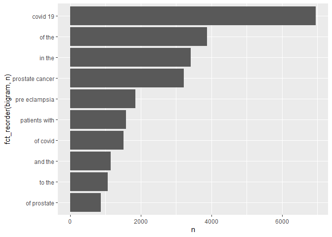

```r
bigabs %>%
  ggplot(aes(n, fct_reorder(bigram, n))) +
  geom_col()
```

## 3. Calculate the TF-IDF value for each word-search term combination.

```r
pubmed %>%
  unnest_tokens(word, abstract) %>%
  count(word, term) %>%
  bind_tf_idf(word, term, n) %>%
  group_by(term) %>%
  arrange(desc(tf_idf), .by_group=TRUE) %>%
  top_n(5,tf_idf) %>%
  knitr::kable()
```

| word | term | n | tf | idf | tf_idf |
| --- | --- | --- | --- | --- | --- |
| covid | covid | 7271 | 0.0370280 | 1.6094379 | 0.0595942 |
| pandemic | covid | 800 | 0.0040740 | 1.6094379 | 0.0065569 |
| coronavirus | covid | 647 | 0.0032949 | 1.6094379 | 0.0053029 |
| sars | covid | 372 | 0.0018944 | 1.6094379 | 0.0030490 |
| cov | covid | 333 | 0.0016958 | 1.6094379 | 0.0027293 |
| cf | cystic fibrosis | 625 | 0.0127144 | 0.9162907 | 0.0116501 |
| fibrosis | cystic fibrosis | 867 | 0.0176374 | 0.5108256 | 0.0090096 |
| cystic | cystic fibrosis | 862 | 0.0175357 | 0.5108256 | 0.0089577 |
| cftr | cystic fibrosis | 86 | 0.0017495 | 1.6094379 | 0.0028157 |
| sweat | cystic fibrosis | 83 | 0.0016885 | 1.6094379 | 0.0027175 |
| meningitis | meningitis | 429 | 0.0091826 | 1.6094379 | 0.0147788 |
| meningeal | meningitis | 219 | 0.0046876 | 1.6094379 | 0.0075444 |
| pachymeningitis | meningitis | 149 | 0.0031893 | 1.6094379 | 0.0051329 |
| csf | meningitis | 206 | 0.0044093 | 0.9162907 | 0.0040402 |
| meninges | meningitis | 106 | 0.0022689 | 1.6094379 | 0.0036516 |
| eclampsia | preeclampsia | 1998 | 0.0142109 | 1.6094379 | 0.0228716 |
| preeclampsia | preeclampsia | 1863 | 0.0132507 | 1.6094379 | 0.0213262 |
| pregnancy | preeclampsia | 969 | 0.0068921 | 0.5108256 | 0.0035207 |
| maternal | preeclampsia | 797 | 0.0056687 | 0.5108256 | 0.0028957 |
| gestational | preeclampsia | 191 | 0.0013585 | 1.6094379 | 0.0021864 |
| prostate | prostate cancer | 3832 | 0.0311735 | 1.6094379 | 0.0501718 |
| androgen | prostate cancer | 305 | 0.0024812 | 1.6094379 | 0.0039933 |
| psa | prostate cancer | 282 | 0.0022941 | 1.6094379 | 0.0036922 |
| prostatectomy | prostate cancer | 215 | 0.0017490 | 1.6094379 | 0.0028150 |
| castration | prostate cancer | 148 | 0.0012040 | 1.6094379 | 0.0019377 |

## Conclusion:

Only “prostate” is listed in the most frequent tokens with “prostate cancer”.

“eclampsia”, “preeclampsia” and “pregnancy” are the most frequent tokens of “preeclampsia”.

“cf”, “fibrosis” and “cystic” are the most frequent tokens of “cystic fibrosis”.

“covid” and “pandemic” are the most frequent tokens of “covid”.